# 手写一个简易的一元线性回归 $ - $ UCI共享单车数据集

## 数据集

这篇文章使用的数据集来自加利福尼亚大学尔湾分校的线上机器学习存储库(UC Irvine Machine Learning Repository)。

该数据集由Hadi Fanaee-T教授于2013年在葡萄牙波尔多大学的人工智能与决策支持实验室（Laboratory of Artificial Intelligence and Decision Support）创建并提供给UC Irvine的机器学习存储库。

数据集的内容是关于美国华盛顿州哥伦比亚特区的共享单车系统。数据集的时间跨度为2011年到2012年。其中包含两份csv文件，其中hour.csv把数据按小时数进行整合，day.csv把数据按照天数进行整合。数据中的特征包括共享单车的使用数量和当时的天气信息等。这篇文章将使用文件day.csv，样本数量为731（天）。

数据集的更多信息可以在UC Irvine的机器学习存储库找到: http://archive.ics.uci.edu/ml/datasets/Bike+Sharing+Dataset

## 读取和可视化数据

首先读取数据：

```python
import pandas as pd
import numpy as np
import matplotlib.pyplot as mplt
from math import ceil, floor
```

```python
day = pd.read_csv("C:/Users/connz/Desktop/to_be_shared/Dataset/Bike Sharing/day.csv")

# 展示day.csv的前5条数据
day.head()
```

|  | instant | dteday | season | yr | mnth | holiday | weekday | workingday | weathersit | temp | atemp | hum | windspeed | casual | registered | cnt |
| --- | --- | --- | --- | --- | --- | --- | --- | --- | --- | --- | --- | --- | --- | --- | --- | --- |
| 0 | 1 | 2011-01-01 | 1 | 0 | 1 | 0 | 6 | 0 | 2 | 0.344167 | 0.363625 | 0.805833 | 0.160446 | 331 | 654 | 985 |
| 1 | 2 | 2011-01-02 | 1 | 0 | 1 | 0 | 0 | 0 | 2 | 0.363478 | 0.353739 | 0.696087 | 0.248539 | 131 | 670 | 801 |
| 2 | 3 | 2011-01-03 | 1 | 0 | 1 | 0 | 1 | 1 | 1 | 0.196364 | 0.189405 | 0.437273 | 0.248309 | 120 | 1229 | 1349 |
| 3 | 4 | 2011-01-04 | 1 | 0 | 1 | 0 | 2 | 1 | 1 | 0.200000 | 0.212122 | 0.590435 | 0.160296 | 108 | 1454 | 1562 |
| 4 | 5 | 2011-01-05 | 1 | 0 | 1 | 0 | 3 | 1 | 1 | 0.226957 | 0.229270 | 0.436957 | 0.186900 | 82 | 1518 | 1600 |

这篇文章将会使用的变量为：

- **temp**: 标准化摄氏度
- **cnt**: 共享单车的使用数量

其中，将会假设cnt为因变量(Response Variate)，temp为自变量(Explanatory Variate)。

变量的标准化由作者提前完成，标准化的方法可以在数据集的介绍文本（Readme.txt)内找到。

把数据中的变量抽取出来并绘制散点图和直方图：

```python
# 从day.csv抽取变量cnt和temp的列
temp = np.array(day['temp'])
cnt = np.array(day['cnt'])
```

绘制散点图：

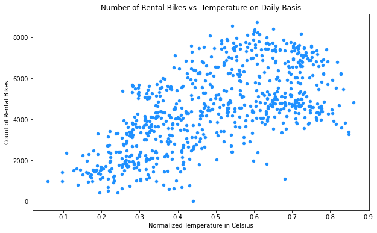

```python
# 用day.csv的数据绘制散点图
mplt.figure(figsize = (10, 6))
mplt.scatter(temp, cnt, s = 20, c = 'dodgerblue')
mplt.xlabel("Normalized Temperature in Celsius")
mplt.ylabel("Count of Rental Bikes")
mplt.title("Number of Rental Bikes vs. Temperature on Daily Basis")
mplt.show()
```

绘制直方图：

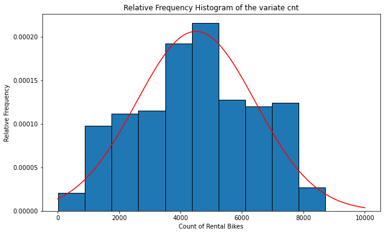

```python
# Normal probability density function
def normfun(x, mu, sigma):
    pdf = np.exp(- ((x - mu) ** 2) / (2 * sigma ** 2)) / (sigma * np.sqrt(2 * np.pi))
    return pdf

x = np.linspace(0, 10000, 10000)
mplt.figure(figsize = (10, 6))
mplt.hist(cnt, density = True, edgecolor = 'black')
mplt.plot(x, normfun(x, np.mean(cnt), np.std(cnt)), c = 'red')
mplt.xlabel("Count of Rental Bikes")
mplt.ylabel("Relative Frequency")
mplt.title("Relative Frequency Histogram of the variate cnt")
mplt.show()
```

可以看出，cnt的行为大致上呈现出了一个正态分布。

因此可以假设变量$y_i$的概率分布模型为$N(\alpha + \beta x_i, \sigma)$, 其中$x_i$为假设的已知常数，$\alpha$ 和 $\beta$ 将通过最小化损失函数而计算出来。

## 损失函数

这里将使用**残差平方和(Sum of Squares of Errors, SSE)** 作为损失函数： $$ SSE = \sum^n_{i = 1}{(y_i - (\alpha + \beta x_i))^2}$$

```python
def loss(x, y, alpha, beta):
    return np.sum((y - (alpha + (beta * x))) ** 2)
```

## 最小二乘估计 $-$ $\hat{\alpha}$, $\hat{\beta}$

损失函数分别对$\alpha$和$\beta$求偏导可得：

$$\frac{\partial} {\partial {\alpha}} \sum^n_{i = 1}{(y_i - (\alpha + \beta x_i))^2} = \sum^n_{i = 1}-2(y_i - (\alpha + \beta x_i)) $$$$\frac{\partial} {\partial {\beta}} \sum^n_{i = 1}{(y_i - (\alpha + \beta x_i))^2} = \sum^n_{i = 1}-2{x_i}(y_i - (\alpha + \beta x_i)) $$

分别让它们等于0可得： $$ \sum^n_{i = 1}-2(y_i - (\hat{\alpha} + \hat{\beta} x_i)) = 0 \qquad (1) $$

$$ \sum^n_{i = 1}-2{x_i}(y_i - (\hat{\alpha} + \hat{\beta} x_i))=0 \quad (2) $$

由（1）可得： $$ \hat{\alpha} = \frac{1}{n} \sum^n_{i=1} y_i - \frac{1}{n}\sum^n_{i=1}\hat{\beta} x_i = \bar{y} - \hat{\beta}\bar{x} $$

将（1）替换进（2）可得： $$ \sum^n_{i=1}{x_i}(y_i - (\bar{y} - \hat{\beta}\bar{x} + \hat{\beta} x_i))=0 \qquad (3)$$

通过解（3）可得出： $$ \hat{\beta} = \frac{\sum^n_{i=1}x_iy_i - n\bar{x}\bar{y}}{\sum^n_{i=1}x_i^2 - n\bar{x}^2} $$

其中 $\bar{x}$ 和 $\bar{y}$ 分别为它们的样本平均值。

```python
# betahat(x, y) consumes an explanatory variate x and
#   a response variate y and calculates the least squares
#   estimate of the regression parameter beta
# betahat: np.array np.array => numbers
# requires: x, y have the same length
#           elements in x and y are numbers
def betahat(x, y):
    n = len(x)
    assert n == len(y), "x and y have different lengths"
    numerator = np.dot(x, y) - (n * np.mean(x) * np.mean(y))
    denominator = np.dot(x, x) - (n * (np.mean(x) ** 2))
    return numerator / denominator


# alphahat(x, y) consumes an explanatory variate x and
#  a response variate y and calculates the least squares
#  estimate of the regression parameter alpha
# alphahat: np.array np.array => numbers
# requires: x, y have the same length
#           elements in x and y are numbers
def alphahat(x, y):
    n = len(x)
    assert n == len(y), "x and y have different lengths"
    return np.mean(y) - (betahat(x, y) * np.mean(x))
```

由此可以计算出 $\hat{\alpha}$ 和 $\hat{\beta}$ 的值：

```python
slope = betahat(temp, cnt)
intercept = alphahat(temp, cnt)
print("The least squares estimate of the slope is", slope, "\n")
print("The least squares estimate of the intercept is", intercept, "\n")
```

```
The least squares estimate of the slope is 6640.709998548637

The least squares estimate of the intercept is 1214.6421190294018
```

由此得出的线性回归模型为：

$$ y = \hat{\beta} x + \hat{\alpha} $$

其中 $\hat{\beta}$ = **6640.709998548637** , $\hat{\alpha}$ = **1214.6421190294018**

将模型画出来可以看到效果：

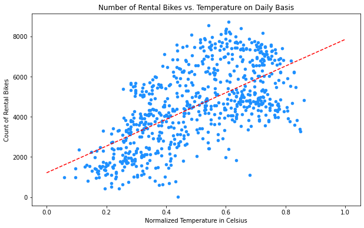

```python
t = np.linspace(0, 1, 100)
mplt.figure(figsize = (10, 6))
mplt.scatter(temp, cnt, s = 20, c = 'dodgerblue')
mplt.plot(t, alphahat(temp, cnt) + (betahat(temp, cnt) * t), linestyle = '--', c = 'red')
mplt.xlabel("Normalized Temperature in Celsius")
mplt.ylabel("Count of Rental Bikes")
mplt.title("Number of Rental Bikes vs. Temperature on Daily Basis")
mplt.show()
```

此模型的损失为：

```python
print("The loss is:", loss(temp, cnt, intercept, slope))
```

```
The loss is: 1660846806.8769715
```

由于变量 cnt 的观察值较大，可以看到损失的数值也因此较大。

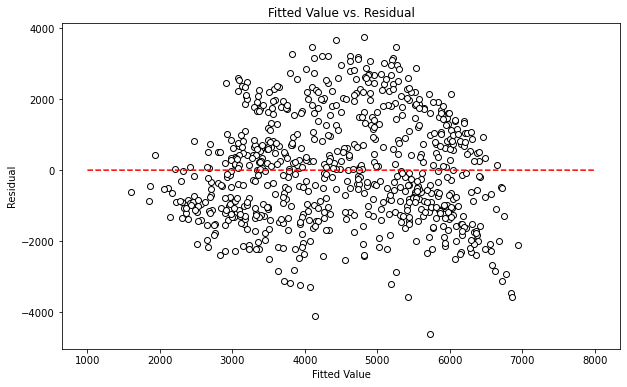

```python
# fitted(x, y) consumes an explanatory variate x and
#  a response variate y and calculates the fitted values
# fitted: np.array np.array => np.array
# requires: x, y have the same length
#           elements in x and y are numbers
def fitted(x, y):
    return (betahat(x, y) * x) + alphahat(x, y)


# residual(x, y) consumes an explanatory variate x and
#  a response variate y and calculates the residuals
# residual: np.array np.array => np.array
# requires: x, y have the same length
#           elements in x and y are numbers
def residual(x, y):
    return y - fitted(x, y)


f = np.linspace(1000, 8000, 100000)
mplt.figure(figsize = (10, 6))
mplt.scatter(fitted(temp, cnt), residual(temp, cnt), color = 'white', edgecolor = "black")
mplt.plot(f, np.zeros(len(f)), c = 'red', linestyle = '--')
mplt.xlabel("Fitted Value")
mplt.ylabel("Residual")
mplt.title("Fitted Value vs. Residual")
mplt.show()
```

## 总结

对于共享单车的使用数量和温度的线性关系假设只在一定程度上存在合理性。随着温度升高变暖和，越来越多人会走出家门到室外去锻炼。然而，随着温度变得过高，愿意走出门去室外的人应该会再次减少，意味着共享单车的使用数量会再次下降。因此，共享单车使用量和温度的线性关系只有在一定的温度范围内存在合理性。由于温度过低或过高都会导致人们出门的欲望降低，或许使用一个非线性模型能够在一个更大的温度范围内存在合理性。

## 代码整理

```python
class SimpleLinearRegression:

    def __init__(self, csv_data, x, y, x_max = None, x_min = None, show = True, colour = 'dodgerblue', describe = True):
        data = csv_data
        title = "%s vs. %s"%(x, y)
        explanatory = np.array(data['%s'%x])
        response = np.array(data['%s'%y])
        if show:
            self.plot_model(explanatory, response, x, y, x_max, x_min, title, colour)
        if describe:
            print("Linear Model:\n\t x = %s, y = %s"%(x, y), "\n")
            print("Intercept = ", alphahat(explanatory, response))
            print("Slope = ", betahat(explanatory, response), "\n")

    def betahat(self, x, y):
        n = len(x)
        assert n == len(y), "x and y have different lengths"
        numerator = np.dot(x, y) - (n * np.mean(x) * np.mean(y))
        denominator = np.dot(x, x) - (n * (np.mean(x) ** 2))
        return numerator / denominator

    def alphahat(self, x, y):
        n = len(x)
        assert n == len(y), "x and y have different lengths"
        return np.mean(y) - (betahat(x, y) * np.mean(x))

    def plot_model(self, x, y, xlabel, ylabel, x_max, x_min, title, colour):
        left_end = x_min if x_min != None else floor(x.min())
        right_end = x_max if x_max != None else ceil(x.max())
        t = np.linspace(left_end, right_end, 100)
        mplt.figure(figsize = (10, 6))
        mplt.scatter(x, y, s = 20, c = colour)
        mplt.plot(t, alphahat(x, y) + (betahat(x, y) * t), linestyle = '--', c = 'red')
        mplt.xlabel("%s"%xlabel)
        mplt.ylabel("%s"%ylabel)
        mplt.title(title)
        mplt.show()
```

#### 分别对 temp, atmp, hum, 和 windspeed 与 cnt 应用 SimpleLinearRegression：

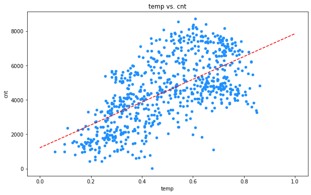

```
Linear Model:
	 x = temp, y = cnt

Intercept =  1214.6421190294018
Slope =  6640.709998548637
```

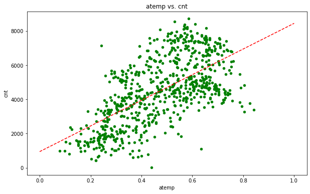

```
Linear Model:
	 x = atemp, y = cnt

Intercept =  945.8239810984928
Slope =  7501.833949516504
```

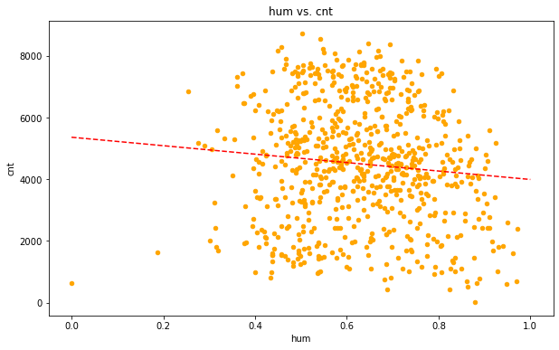

```
Linear Model:
	 x = hum, y = cnt

Intercept =  5363.986453971231
Slope =  -1369.0806578962527
```

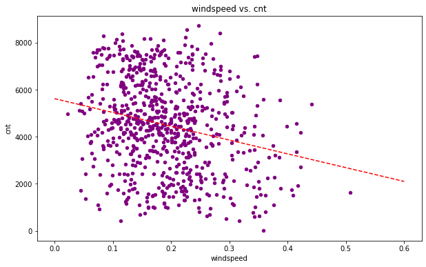

```
Linear Model:
	 x = windspeed, y = cnt

Intercept =  5621.152878047154
Slope =  -5862.9127604227915
```

```
<__main__.SimpleLinearRegression at 0x26892dd33a0>
```

```python
SimpleLinearRegression(day, 'temp', 'cnt')
SimpleLinearRegression(day, 'atemp', 'cnt', colour = "green")
SimpleLinearRegression(day, 'hum', 'cnt', colour = "orange")
SimpleLinearRegression(day, 'windspeed', 'cnt', colour = "purple", x_min = 0, x_max = 0.6)
```

从上面的结果可以看出变量 hum 和 windspeed 并没有与变量 cnt 呈现出明显的线性关系, 因此线性回归模型并不能很好的描述 hum, windspeed 与 cnt 之间的关系。